# NEPA Decarbonization Technology Analysis: Deliverable 1

Why NEPA Was Triggered — Classifying the Federal Nexus

Published

August 21, 2026

## Executive Summary

**NoteKey Findings**

- **Funding is the dominant NEPA trigger, accounting for 9,210 projects (44.4%).** DOE’s grant and loan guarantee portfolio is the single largest source of decarbonization NEPA reviews.
- **Land is the second-largest class, at 3,801 projects (18.3%).** These are BLM and Forest Service right-of-way and special use permits for utility-scale renewables on public land.
- **PMA/TVA is third, at 3,535 projects (17.1%).** The federal power marketing administrations (BPA, WAPA, SEPA, SWPA) and the Tennessee Valley Authority act as project proponent for transmission and power infrastructure.
- **Direct Action is fourth, at 3,181 projects (15.3%).** It is driven overwhelmingly by DOE building, operating, and modifying its own facilities, including national laboratories and site operations.
- **Review process profiles differ by trigger class.** Categorical Exclusions are dominated by Funding (DOE’s CE authority for grants), Environmental Impact Statements skew toward Land and PMA/TVA, and Environmental Assessments show the most balanced trigger mix.
- **Trigger class predicts regulatory intensity.** Funding projects are overwhelmingly CEs, while Land and Permit generate proportionally more EAs and EISs, reflecting the heavier review burden that land disturbance and regulatory licensing carry relative to financial assistance.
- **Technology patterns reflect nexus logic.** Transmission has the highest PMA/TVA share (BPA and WAPA build and maintain federal lines); Solar and Wind split between Land (BLM right-of-way) and Funding (DOE grants); and CCS and Energy Storage skew toward Funding via DOE emerging-technology programs.

This report delivers:

> Reasons why NEPA was triggered (e.g., federal land, federal funding) for different types of projects.

# Methodology

## Trigger Definitions

NEPA applies whenever a federal nexus exists—but the *nature* of that nexus varies. We classify each project into one of eight mutually exclusive primary trigger classes using a strict priority ordering (highest to lowest). When evidence points to multiple classes, the higher-priority class wins as the primary; lower-priority matches are retained as secondary triggers.

| Trigger | Federal Nexus |
| --- | --- |
| **Program** | A programmatic EIS, land-use plan, or rulemaking umbrella covers the action — the NEPA review is at the policy or program level |
| **Direct Action** | The federal agency is the proposer — building, operating, or managing the project (e.g., agency construction, national laboratory operations, military facilities) |
| **PMA/TVA** | A federal power marketing administration (BPA, WAPA, SEPA, SWPA) or the Tennessee Valley Authority is the acting agency — building, upgrading, or maintaining federal power and transmission infrastruct… |
| **Property Transaction** | A land exchange, disposal, or conveyance of federal property is the triggering event |
| **Land** | A private or state actor seeks a right-of-way, special use permit, or lease on federal land (BLM, National Forest) |
| **Permit** | A federal license or permit issued by a regulatory body (FERC license, FAA authorization, Section 404 dredge-and-fill) is the primary nexus |
| **Funding** | Federal grant, loan guarantee, or financial assistance is the trigger (DOE loan program, IRA grant, Rural Energy for America Program) |
| **Unknown** | NEPA is confirmed but the trigger cannot be reliably identified from available text or metadata |

All five classification tiers obey this priority ordering. Tiers 0–4 enforce it mechanically (each rule detects a single class, and the ladder settles conflicts). Tier 5—the LLM fallback—proposes both the classes and its own ranking; the pipeline reconciles that ranking to the fixed hierarchy at ingest, so every published primary follows the ordering above. The LLM’s raw verdicts are preserved verbatim in a committed adjudication record ([`tier5_adjudication_record.csv`](https://github.com/kaseyzapatka/nepa/blob/main/phase2/code/deliverable01/tier5_adjudication_record.csv)), and the published Tier 5 classifications can be reproduced exactly—without any LLM call—by running `03_rerun_tier5.py --from-record` against that record.

## Workflow

The approach spends effort where it is needed. Cheap deterministic rules classify everything they can; machine-learning models take the bulk that rules cannot reach; and a carefully audited LLM pass handles only the hardest residue. Every automated judgment is gated, logged, and reproducible.

1 · Scope

All 20,725 decarbonization projects in NEPATEC 2.0 — every CE, EA, and EIS — each to be assigned one of eight federal-nexus classes answering **why NEPA applied**

↓

2 · Deterministic rules first

Hand-labeled seed cases, agency-jurisdiction lookups (FERC → Permit; BLM → Land; BPA/WAPA → PMA/TVA), and text-pattern rules on titles, descriptions, and purpose-and-need sections resolve nearly half the universe (48%) with no model at all

↓

3 · Local models for the bulk

A SetFit classifier fine-tuned on the labeled example bank reads the ~10K ambiguous DOE Categorical Exclusions; an NLI cross-encoder adjudicates the rest against retrieved document evidence, accepting only projects that clear three evidence gates — together lifting resolution to 97.6%

↓

4 · LLM fallback for the residue

Claude (Haiku) reads the retrieved evidence for the 501 projects nothing else could settle, abstaining when the evidence is genuinely uninformative. Every verdict is reconciled to the fixed priority hierarchy and frozen in a committed adjudication record — the published classifications replay exactly, with no API call

↓

5 · Validate, analyze, report

Row-count and coverage gates, a human spot-check of the LLM's answers, and figures computed live from the published data — 99.6% of projects classified, the 0.4% residue flagged for manual review

The five steps of the classification — the pipeline chart below shows each tier's yield.

## Classification Pipeline

Trigger classification runs in five tiers plus a manual-label seed. Each tier feeds into the next; a project is finalized the moment it clears a tier’s acceptance gate and is never re-processed by later tiers. This preserves precision at each level while reserving compute- intensive methods for the genuinely ambiguous cases.

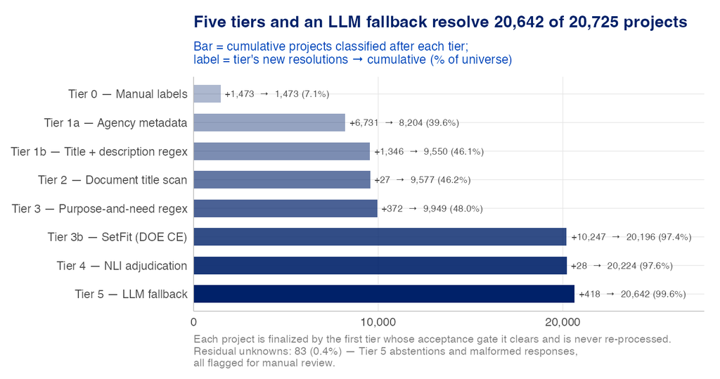

Figure 1: Cumulative trigger resolution across the classification pipeline. Each project is finalized by the first tier whose acceptance gate it clears; the 83 residual unknowns are flagged for manual review.

| Tier | Projects | Resolved (cum.) | % of Universe |
| --- | --- | --- | --- |
| Tier 0 — Manual labels | 1,473 | 1,473 | 7.1% |
| Tier 1a — Agency metadata | 6,731 | 8,204 | 39.6% |
| Tier 1b — Title + description | 1,346 | 9,550 | 46.1% |
| Tier 2 — Document title scan | 27 | 9,577 | 46.2% |
| Tier 3 — Purpose-and-need | 372 | 9,949 | 48.0% |
| Tier 3b — SetFit (DOE CE) | 10,247 | 20,196 | 97.4% |
| Tier 4 — NLI adjudication | 28 | 20,224 | 97.6% |
| Tier 5 — LLM fallback | 418 | 20,642 | 99.6% |
| — Unknown | 83 | — | 0.4% |

**Total resolved: 20,642 / 20,725 (99.6%).** Per-tier methods (rule sets, model configurations, acceptance gates) are documented in the [architecture doc](https://github.com/kaseyzapatka/nepa/blob/main/phase2/architecture/deliverables/deliverable01.md).

The pipeline is implemented in [`phase2/code/deliverable01/01_extract_nepa_trigger.py`](https://github.com/kaseyzapatka/nepa/blob/main/phase2/code/deliverable01/01_extract_nepa_trigger.py). The full output schema is documented in [`phase2/architecture/deliverables/deliverable01.md`](https://github.com/kaseyzapatka/nepa/blob/main/phase2/architecture/deliverables/deliverable01.md).

## Evidence Sources

The table below shows how many projects were classified from each evidence source and at what confidence level. Agency Metadata reflects Tier 1a deterministic mappings; Purpose and Need and Project Description reflect document-level text extraction (Tiers 1b–3); Document Title reflects Tier 2 document title scanning.

Table 1: Trigger classification counts by evidence source and confidence level.

[output not shown]

Coverage rates, residual-unknown composition, confidence tiers, and the caveats that should accompany any reuse of this data are collected on the Coverage & Limitations page.

# Trigger Distribution Overview

Figure 2 shows the total number of decarbonization projects in each primary trigger class. Funding is by far the largest class: DOE’s grant and loan guarantee portfolio generates more NEPA reviews than any other federal nexus. Land is second, reflecting utility-scale renewables sited on BLM and National Forest lands under right-of-way or special use permits. PMA/TVA is third, as the federal power marketing administrations (BPA, WAPA) and TVA build and operate transmission and generation infrastructure directly. Direct Action is fourth, driven almost entirely by DOE actions at its own facilities, including national laboratories and site operations.

Permit, Program, and Property Transaction together account for 915 projects (4.4%)— these are real but narrow categories of federal nexus.

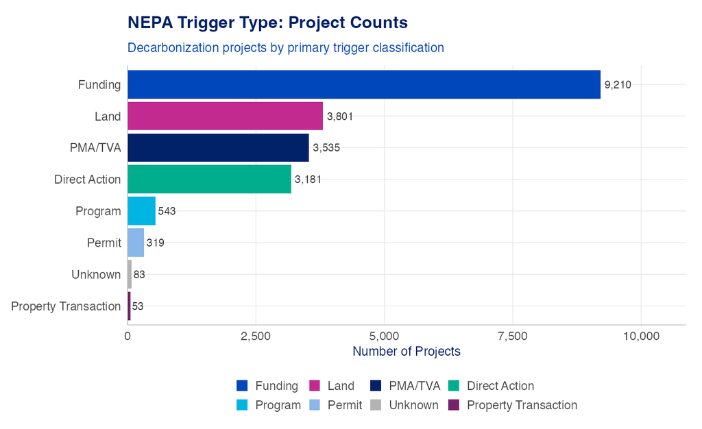

Figure 2: Primary NEPA trigger counts across 20,725 decarbonization projects. Colors match the trigger legend used throughout this report.

# Trigger Type by Review Process

## How triggers distribute across CE, EA, and EIS

Figure 3 shows what share of each review process is driven by each trigger class. The three processes reveal distinct trigger profiles:

- Categorical Exclusions are dominated by Funding—DOE’s clean energy grant and loan programs generate a high volume of low-complexity actions that qualify for CE-level review.
- Environmental Assessments show a more balanced mix: Land (BLM/USFS right-of-way grants for solar and wind) and PMA/TVA (federal transmission projects) each contribute meaningfully alongside Funding.
- Environmental Impact Statements skew heavily toward Land, PMA/TVA, and Permit—larger, more complex projects requiring full EIS review tend to be sited on public lands, be federally constructed transmission, or carry FERC licensing.
- Unknowns are now a small residual across all three processes (0.4% of the portfolio overall). The Tier 5 LLM pass resolved most of the previously-large EA and EIS uncertain pools; the unknowns that remain—still modestly more common in EAs and EISs than in CEs—are the long-document cases where neither Tier 4 nor the LLM found decisive trigger evidence.

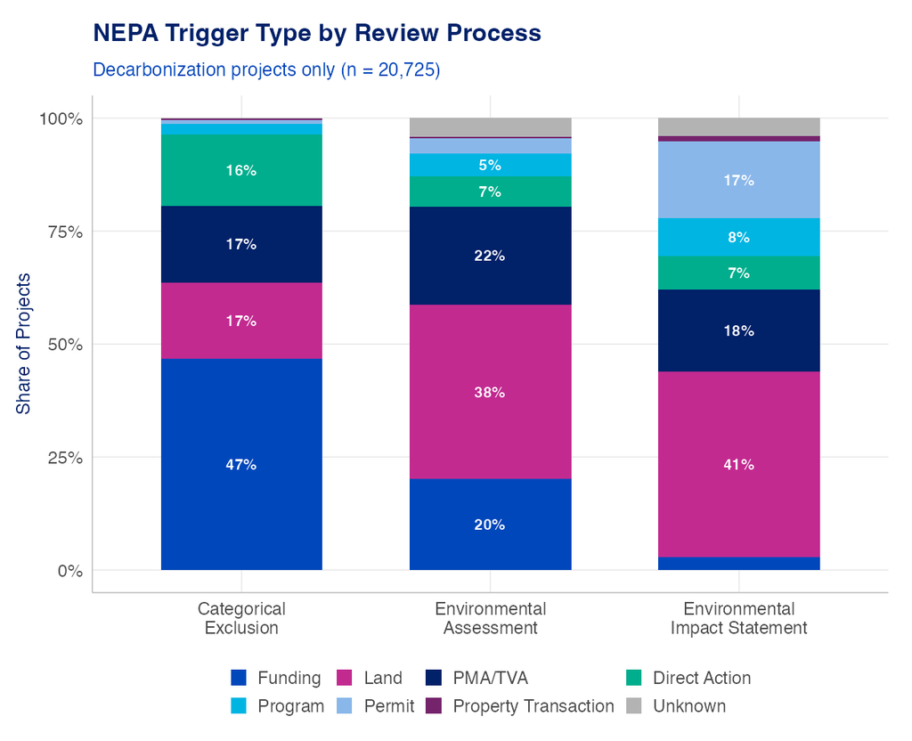

Figure 3: Primary NEPA trigger type by review process across 20,725 decarbonization projects. Percentage labels shown for segments > 5%.

## Typical review pathway by trigger class

Figure 4 inverts the view: for each trigger class, it shows the share of projects that went through CE, EA, or EIS review. This reveals the typical regulatory pathway associated with each nexus type.

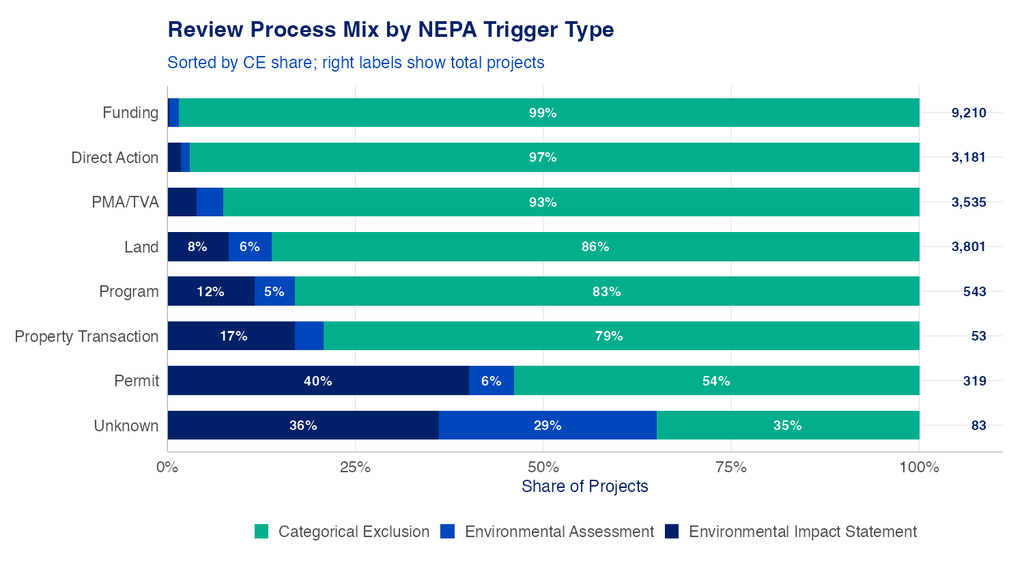

Figure 4: Share of CE, EA, and EIS reviews within each primary trigger class. Percentage labels shown for segments > 5%; right-side labels show total project counts.

# Multi-Label Structure: Secondary Triggers

Every project receives one **primary** trigger — the highest-priority federal nexus the hierarchy resolves — but 1,559 projects (7.5%) carry at least one **secondary** trigger, a second nexus the pipeline detected but ranked below the primary. These secondary labels are stored in `nepa_trigger_secondary`; this section cross-tabulates them to show which nexuses co-occur and where multi-label projects concentrate.

## Which trigger classes co-occur

Figure 5 pairs each multi-label project’s primary trigger (rows) against its secondary trigger(s) (columns). The structure is overwhelmingly dominated by a single pattern.

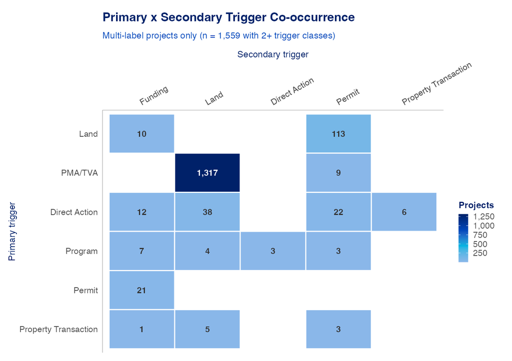

Figure 5: Primary × secondary trigger co-occurrence among multi-label projects. Cell values count projects with that primary/secondary pairing; a project with two secondaries contributes to two cells.

1,310 of the 1,559 multi-label projects (84.0%) share the same combination — **PMA/TVA + Land**: BPA and WAPA transmission and power infrastructure that also crosses BLM or National Forest land, so the power-authority-proponent nexus and the federal-land nexus both apply. Every other combination is a long tail; the next-largest, Land + Permit (111 projects), is roughly a twelfth the size.

Table 2: Dominant trigger combinations among multi-label projects. Share of multi-label denominates by the 1,559 projects with 2+ trigger classes; share of portfolio by all 20,725 decarbonization projects.

| Trigger Combination | Projects | Share of Multi-Label | Share of Portfolio |
| --- | --- | --- | --- |
| PMA/TVA + Land | 1,310 | 84.0% | 6.3% |
| Land + Permit | 111 | 7.1% | 0.5% |
| Direct Action + Land | 34 | 2.2% | 0.2% |
| Permit + Funding | 21 | 1.3% | 0.1% |
| Direct Action + Permit | 16 | 1.0% | 0.1% |
| Direct Action + Funding | 10 | 0.6% | 0.0% |
| Land + Funding | 8 | 0.5% | 0.0% |
| PMA/TVA + Land + Permit | 7 | 0.4% | 0.0% |

## Where multi-label projects concentrate

Multi-label projects are not spread evenly. Figure 6 shows the share carrying a secondary trigger by review process and by energy technology.

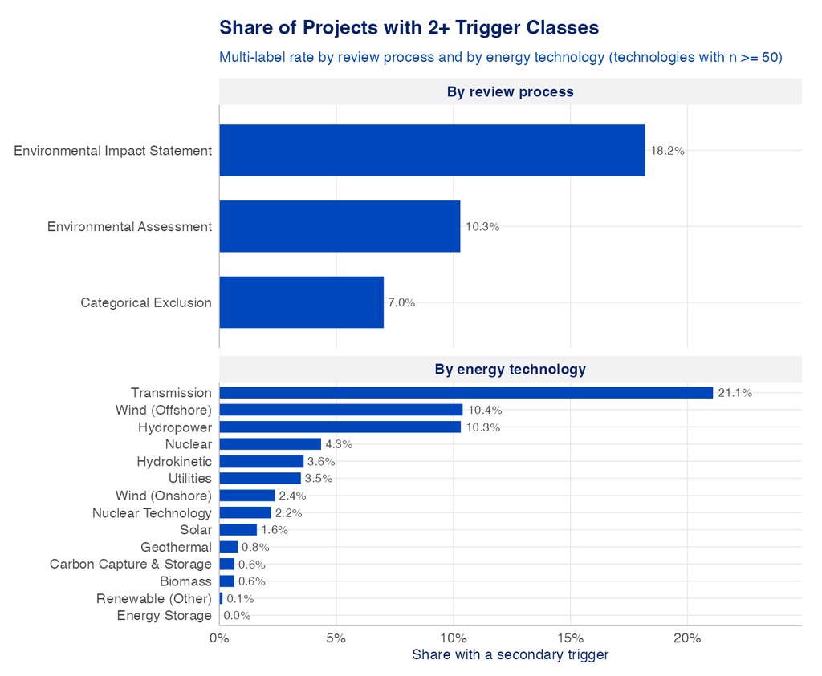

Figure 6: Share of projects with 2+ trigger classes, by review process and by energy technology (technologies with n ≥ 50).

- **Multi-label rates rise with review depth.** EISs carry a secondary trigger 18.2% of the time (EIS), against 7.0% for CEs — the larger, more complex projects that warrant a full EIS are precisely the ones likely to implicate more than one federal nexus.
- **Transmission dominates.** 21.1% of transmission projects are multi-label — more than double any other technology — reflecting the PMA/TVA-plus-federal-land pattern that drives the entire overlap. Offshore wind and hydropower follow at roughly 10%, both siting-heavy technologies that routinely touch a second nexus.

# Trigger Class × Review Status

The natural next question is how trigger class interacts with the kind of NEPA review a project received. The review-type axis — CE vs. EA vs. EIS — is covered in Trigger Type by Review Process above. This section addresses the programmatic vs. tiered dimension: whether a review stands alone or tiers from an umbrella programmatic document.

**NoteData source**

A portfolio-wide programmatic/tiered classifier does not exist in Phase 2. D2’s outputs (significance determinations, regulatory regimes) do not carry a programmatic/tiered flag. The only committed programmatic/tiered signal is D6’s FONSI-enrichment `is_tiered` / `tiers_from` field, which is populated for the FONSI-enriched subset. The cross-tab below uses that source and is scoped accordingly; a full-portfolio tiering classifier remains deferred (see Coverage & Limitations).

## Programmatic tiering by trigger class

Among the 452 FONSI-enriched decarbonization projects, D6 makes an explicit tiering determination for 75; 52 of those tier from a programmatic document. Figure 7 shows how those determinations split across trigger classes.

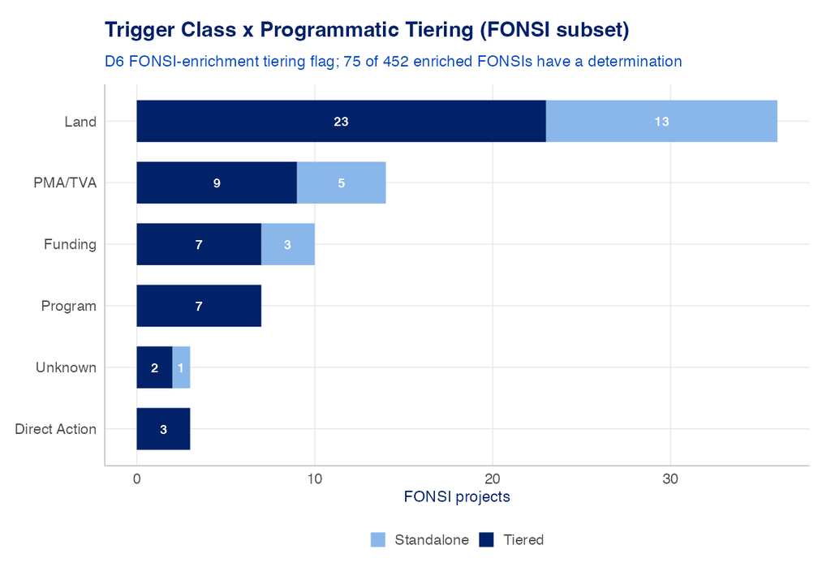

Figure 7: Trigger class × programmatic tiering status, D6 FONSI-enrichment subset. Only classes with ≥ 3 determined FONSIs shown; ‘Tiered’ = review tiers from an umbrella programmatic EIS/EA.

Table 3: Trigger class × programmatic tiering (D6 FONSI-enrichment subset). ‘Determined’ = Tiered + Standalone; the tiered share denominates by the determined count only.

| Trigger Class | Tiered | Standalone | Undetermined | Tiered Share (of determined) |
| --- | --- | --- | --- | --- |
| Land | 23 | 13 | 117 | 64% |
| PMA/TVA | 9 | 5 | 93 | 64% |
| Funding | 7 | 3 | 92 | 70% |
| Program | 7 | 0 | 16 | 100% |
| Direct Action | 3 | 0 | 28 | 100% |
| Unknown | 2 | 1 | 17 | 67% |
| Permit | 1 | 1 | 12 | 50% |
| Property Transaction | 0 | 0 | 2 | — |

**Land-nexus reviews are the ones that tier.** Land is both the most common determined class (36 FONSIs) and the most frequently tiered — 23 of its 36 determined reviews tier from a programmatic document, overwhelmingly BLM’s vegetation-treatment and herbicide PEISs. PMA/TVA and Funding follow. The pattern is intuitive: tiering is a public-lands management device, so it concentrates in exactly the trigger classes tied to BLM and Forest Service land. This is a FONSI-subset signal, not a portfolio rate, and should be read as directional.

## Regulatory review regime by trigger class

For portfolio-scale context, D2’s `project_regime` output assigns each EA/EIS project a regulatory regime keyed to the CEQ rule in force at its decision date. The table below cross-tabulates trigger class against that regime for the 1,326 EA/EIS projects with a regime assignment. This is a regulatory-vintage axis, distinct from the programmatic/tiered question above.

Table 4: Trigger class × regulatory review regime (D2 project_regime; EA/EIS decision universe). ‘Pre-2020 CEQ’ and ‘2020–2025 CEQ rules’ bin the decision-date regime; ‘FRA overlay’ counts projects whose review window overlaps the June 2023 Fiscal Responsibility Act amendments.

| Trigger Class | EA/EIS Projects | Pre-2020 CEQ | 2020–2025 CEQ Rules | Undated | FRA Overlay |
| --- | --- | --- | --- | --- | --- |
| Land | 528 | 258 | 82 | 188 | 31 |
| PMA/TVA | 262 | 111 | 32 | 119 | 11 |
| Permit | 147 | 32 | 8 | 107 | 7 |
| Funding | 138 | 88 | 19 | 31 | 16 |
| Direct Action | 94 | 48 | 11 | 35 | 3 |
| Program | 92 | 43 | 5 | 44 | 2 |
| Unknown | 54 | 26 | 5 | 23 | 5 |
| Property Transaction | 11 | 7 | 0 | 4 | 0 |

Land and PMA/TVA supply the largest EA/EIS caseloads, and both skew toward the pre-2020 CEQ regime — the bulk of these public-lands and transmission reviews predate the 2020–2025 rule churn. Roughly two in five of the regime universe is undated (no reliable decision date recovered), so these counts are lower bounds on each vintage.

# Trigger Distribution by Federal Department

The heatmap reads row by row: each row sums to 100%, showing how a given department’s projects are distributed across trigger classes. For example:

- Department of Energy projects are largely Funding—DOE’s primary mechanism for decarbonization investment is grant and loan programs—with sizable PMA/TVA and Direct Action shares from the power marketing administrations housed within DOE and from DOE’s own facility and laboratory actions.
- Department of the Interior (primarily BLM) projects skew toward Land, as expected given BLM’s public land jurisdiction.
- Department of Agriculture (Forest Service) mirrors Interior but at smaller scale— National Forest special use permits for biomass, wind, and transmission lines.

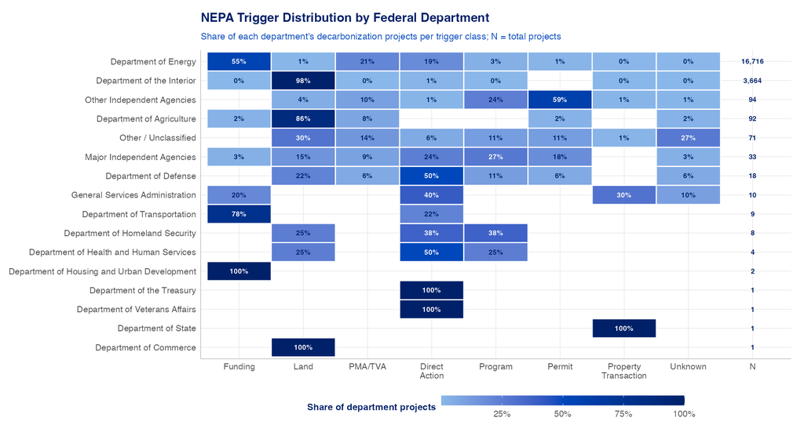

Figure 8: NEPA trigger distribution by federal parent department. Each row sums to 100%. Cell text: share of that department’s decarbonization projects in each trigger class.

# Trigger Distribution by Energy Technology

Figure 9 shows trigger mix across primary clean energy technology types, filtered to technologies with at least 50 projects. Technology assignment uses the first matching clean-energy NEPATEC tag per project (e.g., a project tagged Solar + Utilities is assigned to Solar).

- Solar and Wind (Onshore) projects are driven mainly by Land and Funding—utility-scale renewables either sit on BLM land or receive DOE financial assistance.
- Transmission shows the highest PMA/TVA share, consistent with the Power Marketing Administrations (BPA, WAPA) building and maintaining federal transmission infrastructure.
- Nuclear Technology shows the highest Direct Action share—DOE national laboratory and site actions dominate this category.
- Hydropower shows a distinctive mix of PMA/TVA (federal hydropower and transmission operations) and Permit (FERC licensing for non-federal hydro) alongside Funding.
- Carbon Capture & Storage and Energy Storage skew toward Funding, reflecting DOE’s active grant program for emerging technologies.

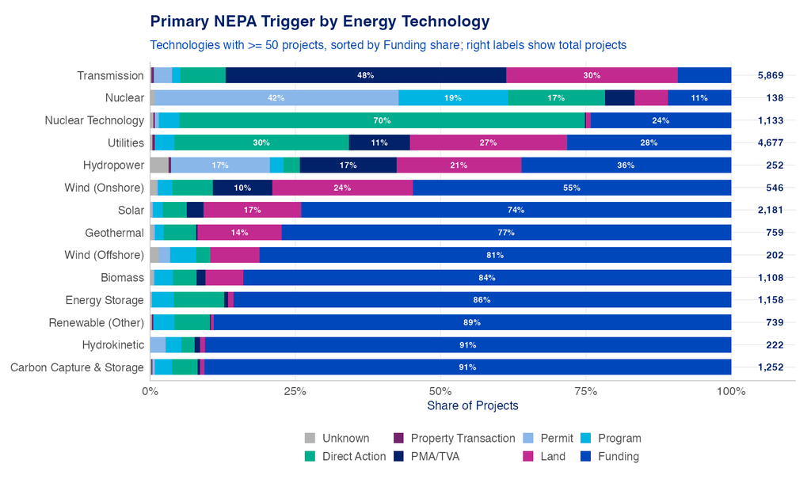

Figure 9: Primary NEPA trigger by energy technology type. Technologies with fewer than 50 projects excluded. Right-side labels show total project counts; technology label = first clean-energy NEPATEC tag per project.

# Federal Funding Deep Dive

The 9,210 Funding-primary projects (44.4% of the portfolio) warrant closer examination of how federal money flows and how much each mechanism typically awards. The figures below use a funding details sidecar produced by the funding mechanism extractor.

## Funding Mechanism Types

Figure 10 breaks down Funding-primary projects by the type of federal financial instrument: grant, loan guarantee, cooperative agreement, cost-share, etc. This reveals the dominant instruments DOE and other agencies use to trigger NEPA review.

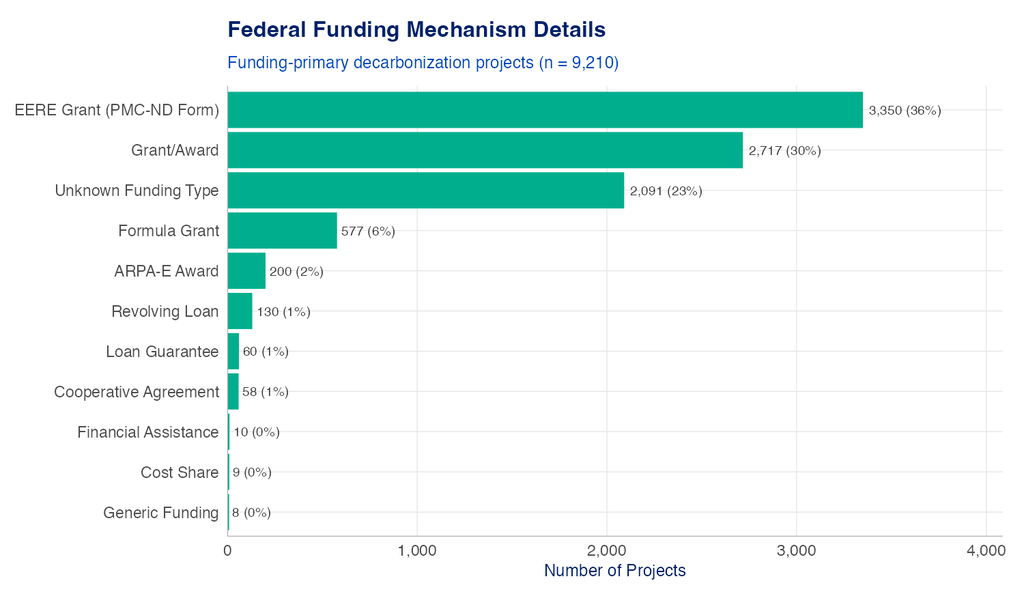

Figure 10: Count and share of Funding-primary decarbonization projects by federal funding mechanism type. Percentages denominated by all Funding-primary projects.

## Funding Program Labels

Figure 11 shows which named federal programs and legislative authorities appear most frequently across Funding-primary projects. Program labels are multi-label — a single project may be linked to multiple programs (e.g., an IRA grant administered under the DOE LPO). Percentages are denominated by all Funding-primary projects.

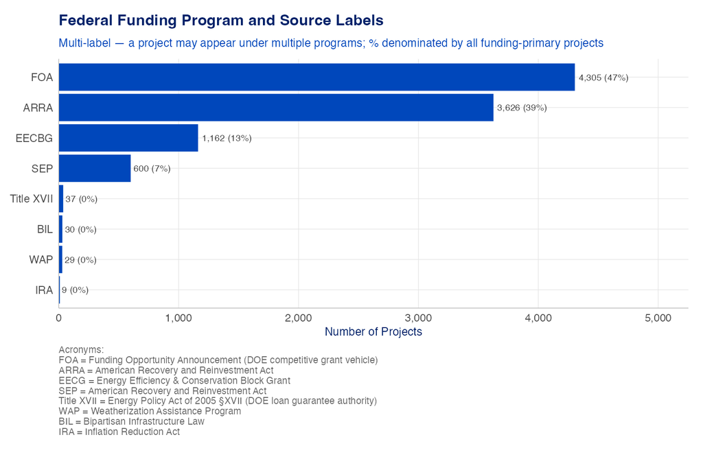

Figure 11: Federal funding program and legislative authority labels across Funding-primary projects. Multi-label: a project may appear under multiple programs.

## Dollar Amount Coverage and Distribution

Figure 12 shows what share of Funding-primary projects have each dollar-amount field successfully extracted. Coverage varies by field type: the federal award amount is most frequently present; recipient cost share and funding percentage require more detailed document language.

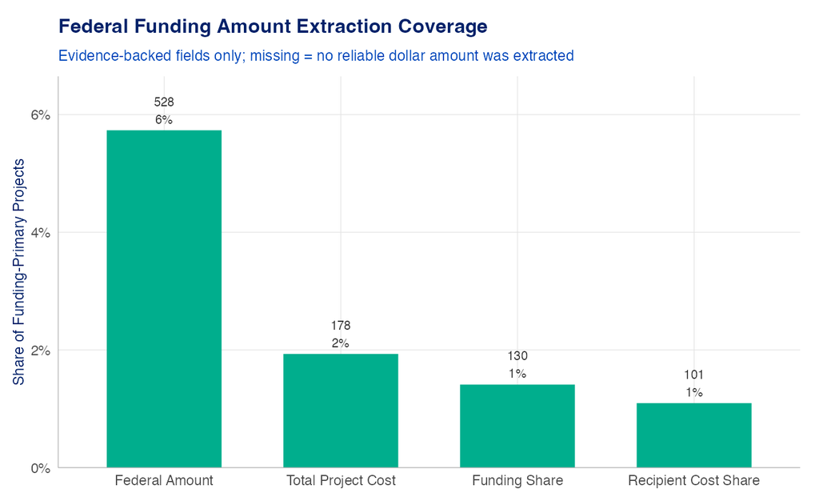

Figure 12: Share of Funding-primary projects with each dollar-amount field extracted. Missing values indicate no reliable figure was found in the document text.

Figure 13 complements the coverage view with the actual dollar distribution per mechanism type. A note on coverage: dollar amounts are extracted only when the document text contains an explicit award figure — most NEPA documents do not. As a result, only a fraction of the 9,210 Funding-primary projects have an extracted amount; the caption reports the exact count. Despite the limited coverage, the distributions are informative about typical award sizes within each mechanism type. Figure 13 focuses on common grant-scale mechanisms, excludes classes with fewer than 10 extracted amounts, and top-codes large grant-scale awards at $5 million so the main distribution remains legible. The larger loan guarantee and cooperative agreement records are shown separately in Table 5.

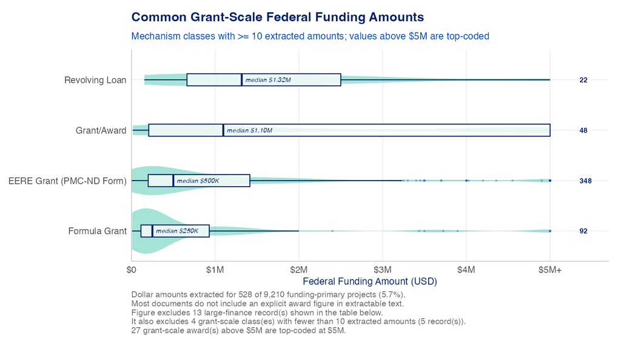

Figure 13: Distribution of common grant-scale federal funding amounts by mechanism type. Classes with fewer than 10 extracted amounts are excluded; values above $5M are top-coded at $5M+. Violin = distribution shape; box = Q1–Q3 with median; right-side labels show extracted amount counts.

Table 5: Large finance mechanisms with extracted federal funding amounts. These 13 loan guarantee and cooperative agreement records are shown as a table rather than scaled with the grant-size distributions.

| Mechanism<sup>1</sup> | Federal Amount | Project | Source Text |
| --- | --- | --- | --- |
| Cooperative Agreement | $475,287,678 | DIII-D National Fusion Program Research and Facility Operations and Advanced Fusion Technology Research and Development | Proposed Action Title: DIII-D National Fusion Program Research and Facility Operations and Advanced Fusion Technology Research and Development Total DOE Funding/Total Funding: $475,287,677.89 Proposed… |
| Cooperative Agreement | $456,394,130 | DIII-D National Fusion Program Research and Facility Operations and Advanced Fusion Technology Research and Development | Total DOE Funding/Total Funding: $456,394,130 Proposed I. |
| Cooperative Agreement | $456,394,130 | DIII-D National Fusion Program Research and Facility Operations and Advanced Fusion Technology Research and Development | Total DOE Funding/Total Funding: $456,394,130 Proposed I. |
| Cooperative Agreement | $25,000,000 | Pacific Gas and Electric Company (PG&E) Compressed Air Energy Storage (CAES) Compression Testing Phase Project | S. Department of Energy (DOE) prepared this final environmental assessment (EA) to evaluate the potential environmental impacts of providing a financial assistance grant for up to $25 million under th… |
| Cooperative Agreement | $13,500,000 | Smart Grid, Center for Commercialization of Electric Technology (CCET), Technology Solutions for Wind Integration in ERCOT | aceted, synergistic approach to managing fluctuations in wind power within the Electric Reliability Council of Texas (ERCOT) transmission grid. DOE’s proposed action would award a $13.5 million financ… |
| Cooperative Agreement | $1,850,000 | Center for Commercialization of Electric Technology (CCET), Reese Technology Center (RTC) Wind and Battery Integration Project | n Recovery and Reinvestment Act of 2009, as part of a cooperative agreement, to the Center for Commercialization of Electric Technology (CCET). DOE’s proposed action would award a $1.85 million financ… |
| Cooperative Agreement | $1,500,000 | DOE’s Proposed Financial Assistance to Pennsylvania for Frey Farm Landfill Wind Energy Project | Pennsylvania proposes to provide the project a $1.5 million grant, which would come from a formula grant Pennsylvania received from DOE pursuant to the Department’s State Energy Program. |
| Cooperative Agreement | $600,000 | Battelle Memorial Institute’s Smart Grid Project at the City of Ellensburg’s Renewable Energy Park, Kittitas County, Washington | Institute (Battelle). This agreement would facilitate expansion of solar energy generation and add wind capacity at the Renewable Energy Park. DOE’s proposed action is to award a $600,000 financial as… |
| Loan Guarantee | $969,000,000 | Monolith Olive Creek Expansion Facility | and Need for Agency Action The proposed action evaluated by the U.S. Department of Energy (DOE) in this environmental assessment (EA) is to issue a loan guarantee in the amount of $969 million to Mono… |
| Loan Guarantee | $535,000,000 | DEPARTMENT OF ENERGY LOAN GUARANTEE TO SOLYNDRA, INC. FOR CONSTRUCTION OF A PHOTOVOLTAIC MANUFACTURING FACILITY AND LEASING OF AN EXISTING COMMERCIAL FACILITY IN FREMONT, CALIFORNIA | ssment ES-1 Proposed Guarantee of Loan to Solyndra, Inc. EXECUTIVE SUMMARY INTRODUCTION The U.S. Department of Energy (DOE) is proposing to issue a loan guarantee in the amount of $535 million to Soly… |
| Loan Guarantee | $241,000,000 | Construction of the Diamond Green Diesel Facility | hington, DC 20585 April 2011 FINAL ENVIRONMENTAL ASSESSMENT Environmental Assessment DOE/EA-1795 i SUMMARY Introduction The U.S. Department of Energy (DOE) is proposing to issue a $241 million loan gu… |
| Loan Guarantee | $5,000,000 | Stion Corporation CIGSS Manufacturing Plant | ciency and Renewable Energy (EERE) Project Management Center (Golden Field Office) issued a National Environmental Policy Act categorical exclusion (GFO-10-599-001) for the use of $5 million in Recove… |
| Loan Guarantee | $2,000,000 | AltAir Fuels | DOE has made a final NEPA determination for this award Insert the following language in the award: Note to Specialist: According to the project officer, funding for this effort is $2,000,000. Unless t… |

<sup>1</sup> DOE is the lead agency for all records shown.

# Geographic Distribution

## State-Level Dominant Trigger

Figure 14 shows the dominant trigger class in each state — the trigger type with the most projects in that state. The map captures broad regional patterns:

- Funding dominates most states, consistent with DOE’s nationwide grant footprint.
- Land dominates in the intermountain West (Nevada, Utah, Wyoming, Montana, Arizona, and New Mexico)—states with high proportions of BLM land and active solar and wind development.
- PMA/TVA dominates states with significant federal power authority infrastructure— Washington and Oregon (BPA) and Colorado and Nebraska (WAPA).
- Direct Action dominates Idaho, West Virginia, and South Carolina—states anchored by DOE national laboratories and site operations (INL, NETL, Savannah River).

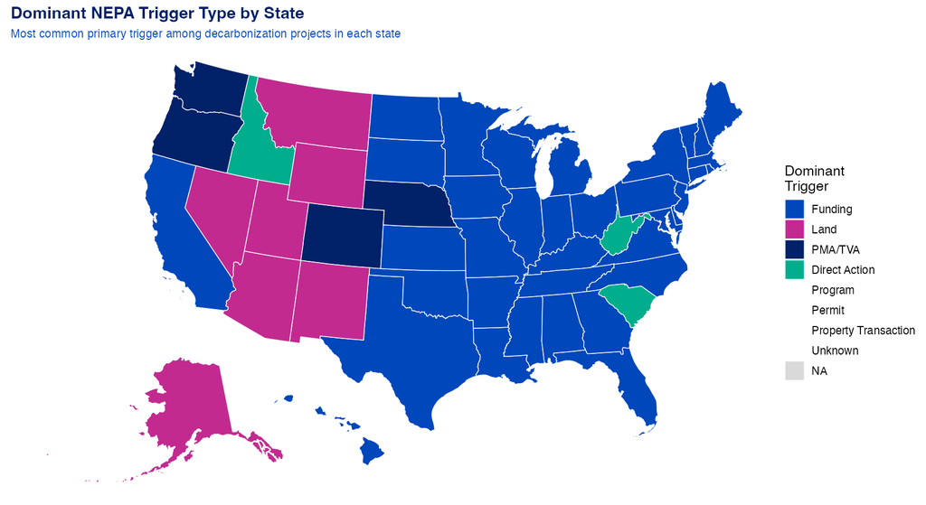

Figure 14: Dominant NEPA trigger by state — the trigger class with the most projects in each state. Grey = no decarbonization projects in NEPATEC 2.0. Alaska and Hawaii repositioned for display.

## County-Level Dominant Trigger

Figure 15 disaggregates the state-level map to the county level, revealing more fine-grained geographic patterns in trigger type. Counties are colored by the dominant trigger class among all decarbonization projects located in that county.

- The Funding / Land boundary maps closely onto federal land ownership: counties spanning BLM or National Forest land (interior West) show Land as dominant; counties without substantial federal land show Funding.
- PMA/TVA clusters in counties with federal power authority infrastructure—Pacific Northwest corridors (BPA transmission), parts of the Midwest, and Southwest transmission hubs.
- Many rural counties host only one or two projects and are therefore colored by a single project’s trigger type; interpret sparse interior counties with caution.

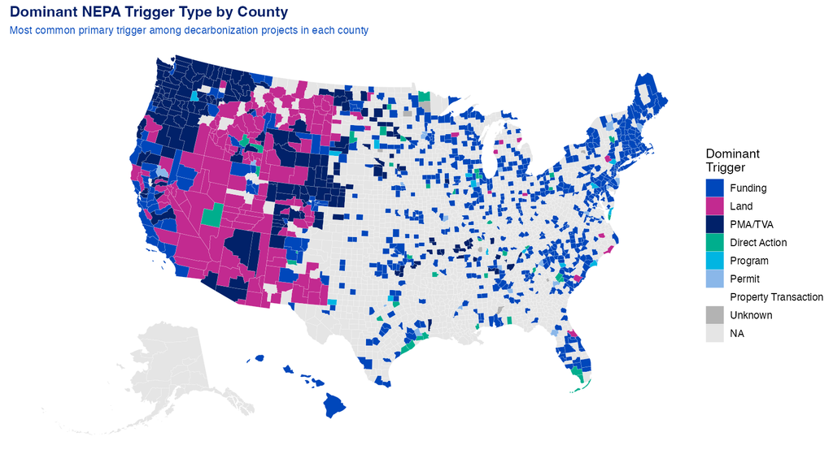

Figure 15: Dominant NEPA trigger by county — the trigger class with the most projects in each county. Counties with no NEPATEC 2.0 decarbonization projects shown in light grey. Alaska and Hawaii repositioned for display.

# Representative Evidence Examples

| Process | Lead Agency | Project | Evidence Text | Source |
| --- | --- | --- | --- | --- |
| Funding |  |  |  |  |
| EA | Department of Energy | Ocean Sequestration of CO2 Field Experiment | “DOE would provide funds for development of experimental plans, public outreach, permitting, data analysis, modeling predictions, and other support functions; the DOE funding would equate to about 20%… | purpose_and_need |
| EA | Energy Programs | Old Town Fuel and Fiber Proposed Demonstration-Scale Inte... | “This EA analyzes the potential environmental and socioeconomic impacts that would result from implementing the Proposed Action (with DOE funding) and the No-Action Alternative (without DOE funding), … | purpose_and_need |
| Land |  |  |  |  |
| EIS | Department of the Interior | Cross-Tie 500-kilovolt Transmission Project | “Cross-Tie 500-kV Transmission Project Draft Environmental Impact Statement Executive Summary ES-1 Executive Summary 1.0 Introduction TransCanyon, LLC (TransCanyon or Applicant), has applied for a rig… | purpose_and_need |
| CE | Department of Agriculture | Special Use Authorization for Electrical Line Realignment... | “The right-of-way will be 20 feet wide and 10,302 feet long, for a total affected area of 4.73 acres. The following mitigation measures will be outlined in construction stipulations that will be made … | description |
| PMA/TVA |  |  |  |  |
| EIS | Department of Energy | San Luis Rio Colorado Project | “The purpose and need for the decisions of the Federal agencies regarding the Proposed Project are discussed below. Western Area Power Administration Western’s decision is to grant or deny an intercon… | purpose_and_need |
| EIS | NA | Southline Transmission Line Project | “The proposed Project would include the construction of approximately 240 miles of new double-circuit 345-kilovolt (kV) transmission line, and the upgrade of approximately 120 miles of Western Area Po… | purpose_and_need |
| Direct Action |  |  |  |  |
| EIS | Department of Energy | Construction and Operation of the Spallation Neutron Source | “20585 Telephone: (202) 586-4600, or leave a message at (800) 472-2756 Facsimile: (202) 586-7031 ABSTRACT: DOE proposes to construct and operate a state-of-the-art, short-pulsed spallation neutron sou… | purpose_and_need |
| EIS | Department of Energy | Strategic Petroleum Reserve Expansion of Reserve | “Description of the Proposed Action : The Department of Energy Administration proposes to implement the S trategic Petroleum Reserve , Titl e I , Part B of the Energy Policy and Conservation Act o f 1… | purpose_and_need |
| Program |  |  |  |  |
| EIS | Nuclear Regulatory Commission | Completion and Operation of Watts Bar Nuclear Plant Unit 2 | “As set forth in the GEIS (generic environmental impact statement), Category 1 issues are those defined as meeting all of the following criteria: Internet Address (URL) http://www.epa.gov Recycled/Rec… | purpose_and_need |
| CE | Department of Energy | Hydrogen Generation and Fueling Station on the STM Campus | “Final Site-Site Wide Environmental Assessment of the National Renewable Energy Laboratory's (NREL) South Table Mountain Complex (February 2003) Rational for determination: BACKGROUND This proposed pr… | description |
| Permit |  |  |  |  |
| EIS | Department of Energy | New England/Hydro-Quebec ± 450 kilovolt Transmission Line... | “The proposed act ion is the issuance of an amendment to Presidential Permit PP-76 to the Vermont Electric Transmiss ion Company to operate the internat ional interconnect ion therein authorized at po… | purpose_and_need |
| EIS | Department of Energy | Eagle Mountain Pumped Storage Hydroelectric Project | “We urge development of more definitive information on the amount of acid rock drainage, prior to the Commission’s approval of the hydropower license.” | purpose_and_need |
| Property Transaction |  |  |  |  |
| EIS | Denali Commission | Mertarvik Infrastructure Development, Nelson Island, Alaska | “This final Environmental Impact Statement (EIS) describes a number of alternatives in a historical context for the purpose of illustrating how the long-term evolution of the project led to the select… | description |

# Reproducibility

Every number and figure in this report is regenerated by committed code, run from the repository root. The one **billable step** — the Tier 5 LLM fallback — never needs to be repeated: its raw verdicts are frozen in a committed adjudication record, and the record replay reproduces the published classifications exactly, with no API call.

```bash
# 1. Full trigger classification, tiers 0–4 (deterministic*, no API key)
conda run -n nepa python phase2/code/deliverable01/01_extract_nepa_trigger.py

# 2. Tier 5 — EXACT replication of the published classifications from the
#    committed record (deterministic, no API key, no cost)
conda run -n nepa python phase2/code/deliverable01/03_rerun_tier5.py \
  --from-record phase2/code/deliverable01/tier5_adjudication_record.csv

#    (alternative: statistical replication by re-running the LLM live —
#     ~$2 at claude-haiku-4-5 pricing; results equivalent in aggregate
#     but not guaranteed row-for-row)
# conda run -n nepa python phase2/code/deliverable01/01_extract_nepa_trigger.py \
#   --use-llm --tier5-budget 25

# 3. Funding sidecar (deterministic; reads the trigger output)
conda run -n nepa python phase2/code/deliverable01/01_extract_nepa_trigger.py \
  --funding-details-only

# 4. Figures + report CSVs (base R, not the nepa env)
Rscript phase2/code/deliverable01/02_create_figures.R

# 4b. Secondary-trigger + review-status cross-tabs (base R; reads D2/D6 outputs)
Rscript phase2/code/deliverable01/04_secondary_review_crosstabs.R

# 5. This report
quarto render phase2/reports/deliverable01.qmd
```

* Tiers 0–3 are exactly deterministic. Tiers 3b/4 run neural inference on Apple MPS without a pinned seed and can drift by a few borderline projects between machines or runs (measured: 1 project between the May and July 2026 runs); any such project enters the Tier 5 queue, where the committed record pins its published classification. See the Coverage & Limitations page and the [architecture doc](https://github.com/kaseyzapatka/nepa/blob/main/phase2/architecture/deliverables/deliverable01.md) for the full reproducibility discussion.

*Report generated 2026-08-21 | NEPA Decarbonization Technology Analysis — Phase 2, Deliverable 1*